# Women in Stats Stats - subset

Dave Campbell

Dec 6, 2024

## Basics

All plots make using RMarkdown. Code is hidden using the **echo = false** flag, but it is available inside the markdown document.

### Updates

- Dec 2024: updated gender categories to reflect latest dataset nomenclature around Gender. **Note:** Some variables will change as gender terminology is updated in future data releases.
- Oct 2023: first plots added

Font “Public Sans” Text size = 22 no background Titles bold background = by hex code. ”

Printing size.

theme_ipsum_rc(base_family = “serif”, base_size = 14) theme(text=element_text(size=16, family=“Public Sans”))

### looks promising

update_geom_font_defaults(family=font_pub)

## Potential Tables

Women in Stats potential

There are 22 rows…

```r
row_2_use = 2
```

## look at some values:

```r
data |> dplyr::filter(GEO == "Canada")|>
    # dplyr::filter(Highest.earned.degree %in% c("PhD (or any equivalent doctoral degree)","Masters","Bachelors"))|>
    dplyr::filter(Highest.earned.degree  == "PhD (or any equivalent doctoral degree)")|>
    dplyr::filter(Rank %in% c("Full professor","Associate professor", "Assistant professor")) |>
    select(where(~ n_distinct(.) > 1))|>
    mutate(Gender = str_replace_all(Gender, pattern = "\n", replacement = ""))|>
    dplyr::filter(Gender != "Total gender")|>
    dplyr::filter(Staff.functions == "Total staff function")|>
    dplyr::filter(Number.and.median == "Number of full time teaching staff")|>
    dplyr::filter(Date == as_date("2022-07-01"))|>
  select(Date,Rank,Gender,VALUE)|>
    group_by(Rank)|>
  mutate(Total_count = sum(VALUE))|>
  mutate(Proportion_gender = VALUE / Total_count)|>
  ungroup()
```

| Date | Rank | Gender | VALUE | Total_count | Proportion_gender |
| --- | --- | --- | --- | --- | --- |
| 2022-07-01 | Full professor | Man | 10755 | 15588 | 0.6899538106 |
| 2022-07-01 | Full professor | Woman | 4824 | 15588 | 0.3094688222 |
| 2022-07-01 | Full professor | Non-binary person and Unknown gender | 9 | 15588 | 0.0005773672 |
| 2022-07-01 | Associate professor | Man | 7470 | 13257 | 0.5634758995 |
| 2022-07-01 | Associate professor | Woman | 5772 | 13257 | 0.4353926228 |
| 2022-07-01 | Associate professor | Non-binary person and Unknown gender | 15 | 13257 | 0.0011314777 |
| 2022-07-01 | Assistant professor | Man | 3447 | 6966 | 0.4948320413 |
| 2022-07-01 | Assistant professor | Woman | 3465 | 6966 | 0.4974160207 |
| 2022-07-01 | Assistant professor | Non-binary person and Unknown gender | 54 | 6966 | 0.0077519380 |

```r
data |> dplyr::filter(GEO == "Canada")|>
    # dplyr::filter(Highest.earned.degree %in% c("PhD (or any equivalent doctoral degree)","Masters","Bachelors"))|>
    dplyr::filter(Highest.earned.degree  == "PhD (or any equivalent doctoral degree)")|>
    select(where(~ n_distinct(.) > 1))|>
    dplyr::filter(Rank %in% c( "Assistant professor")) |>
    # dplyr::filter(Rank %in% c("Full professor","Associate professor", "Assistant professor")) |>
    mutate(Gender = str_replace_all(Gender, pattern = "\n", replacement = ""))|>
    dplyr::filter(Gender != "Total gender")|>
    dplyr::filter(Staff.functions == "Total staff function")|>
    dplyr::filter(Number.and.median == "Number of full time teaching staff")|>
    dplyr::filter(Date >= as_date("2020-07-01"))|>
  select(REF_DATE,Date,Rank,Gender,VALUE)|>
  # pivot_wider(names_from = Gender, values_from = VALUE)
    group_by(Rank,Date)|>
  mutate(Total_count = sum(VALUE))|>
  mutate(Proportion_gender = VALUE / Total_count)|>
  ungroup()
```

| REF_DATE | Date | Rank | Gender | VALUE | Total_count | Proportion_gender |
| --- | --- | --- | --- | --- | --- | --- |
| 2019/2020 | 2020-07-01 | Assistant professor | Man | 3492 | 6765 | 0.516186253 |
| 2019/2020 | 2020-07-01 | Assistant professor | Woman | 3270 | 6765 | 0.483370288 |
| 2019/2020 | 2020-07-01 | Assistant professor | Non-binary person and Unknown gender | 3 | 6765 | 0.000443459 |
| 2020/2021 | 2021-07-01 | Assistant professor | Man | 3522 | 6933 | 0.508005193 |
| 2020/2021 | 2021-07-01 | Assistant professor | Woman | 3402 | 6933 | 0.490696668 |
| 2020/2021 | 2021-07-01 | Assistant professor | Non-binary person and Unknown gender | 9 | 6933 | 0.001298139 |
| 2021/2022 | 2022-07-01 | Assistant professor | Man | 3447 | 6966 | 0.494832041 |
| 2021/2022 | 2022-07-01 | Assistant professor | Woman | 3465 | 6966 | 0.497416021 |
| 2021/2022 | 2022-07-01 | Assistant professor | Non-binary person and Unknown gender | 54 | 6966 | 0.007751938 |
| 2022/2023 | 2023-07-01 | Assistant professor | Man | 3387 | 7149 | 0.473772556 |

[output cut: 5 more lines]

## Make some plots of 37-10-0077-01 describing Number and median age of full-time teaching staff at Canadian universities, by highest earned degree, staff functions, rank, gender

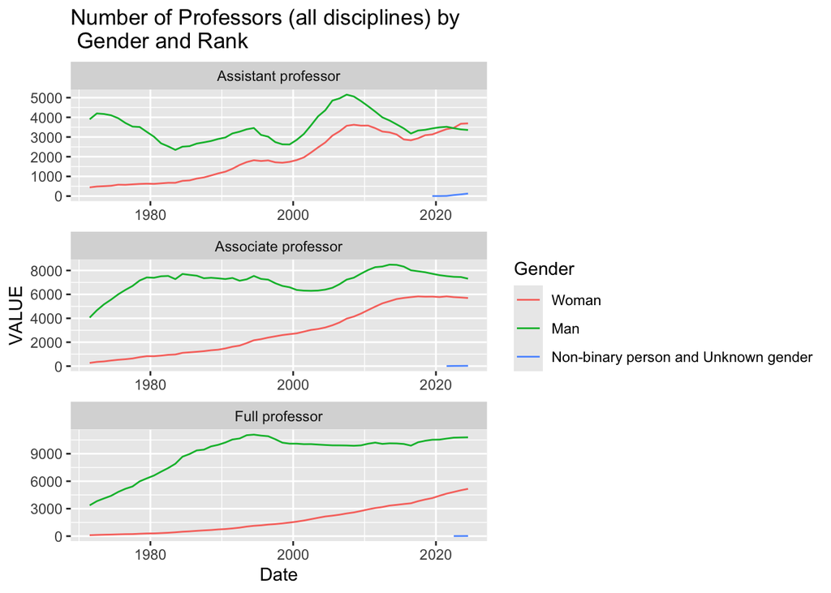

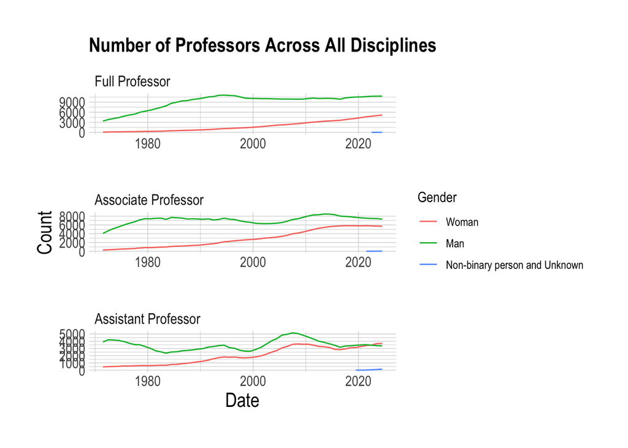

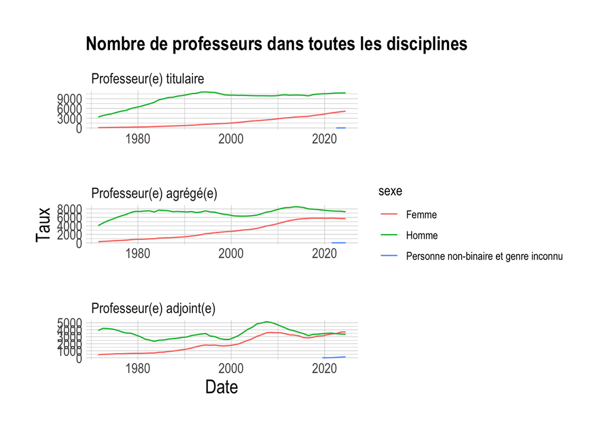

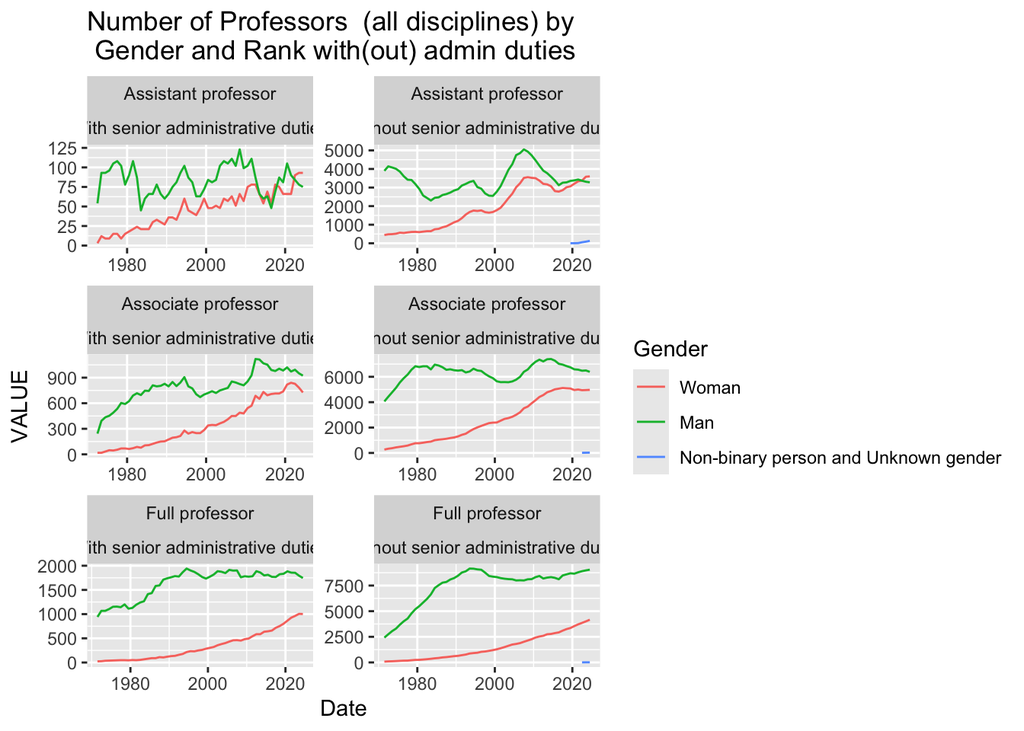

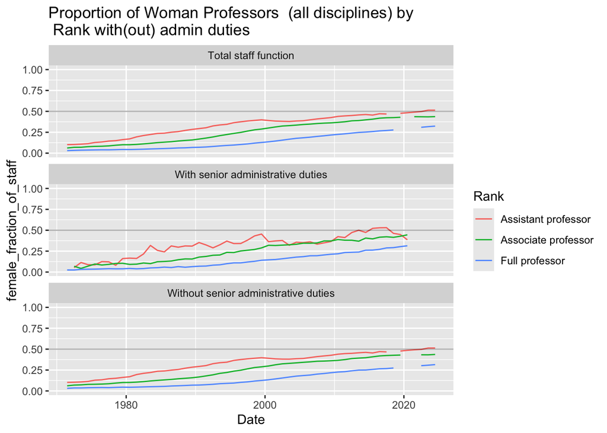

```r
row_2_use = 3
```

## Make some plots of 37-10-0144-01 describing Number and proportion of full-time teaching staff at Canadian universities by academic rank and gender

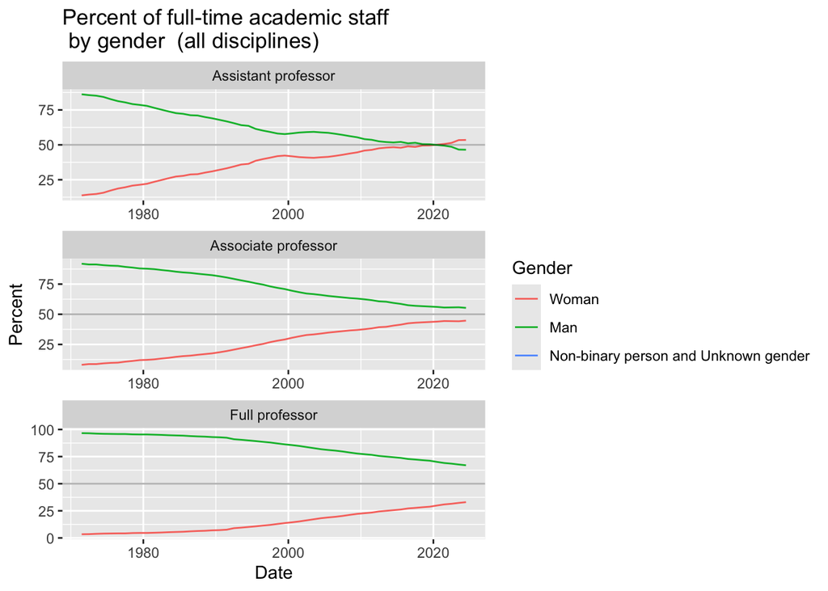

```r
row_2_use = 7
```

## Make some plots of 37-10-0235-01 describing Postsecondary graduates, by detailed field of study, institution, and program and student characteristics, inactive

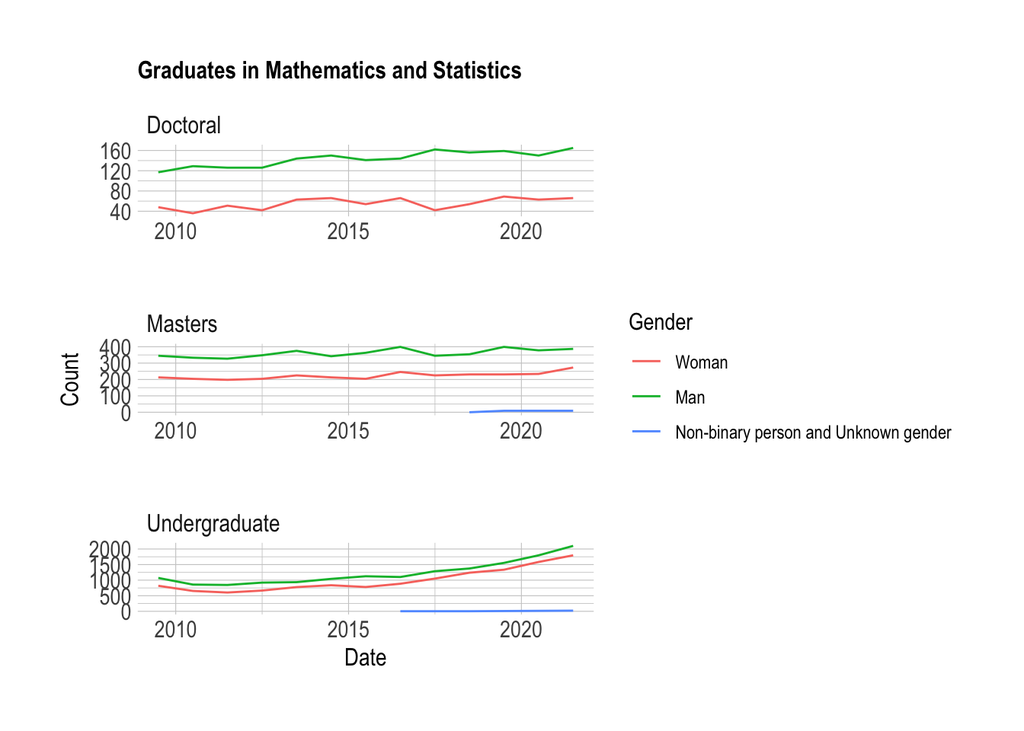

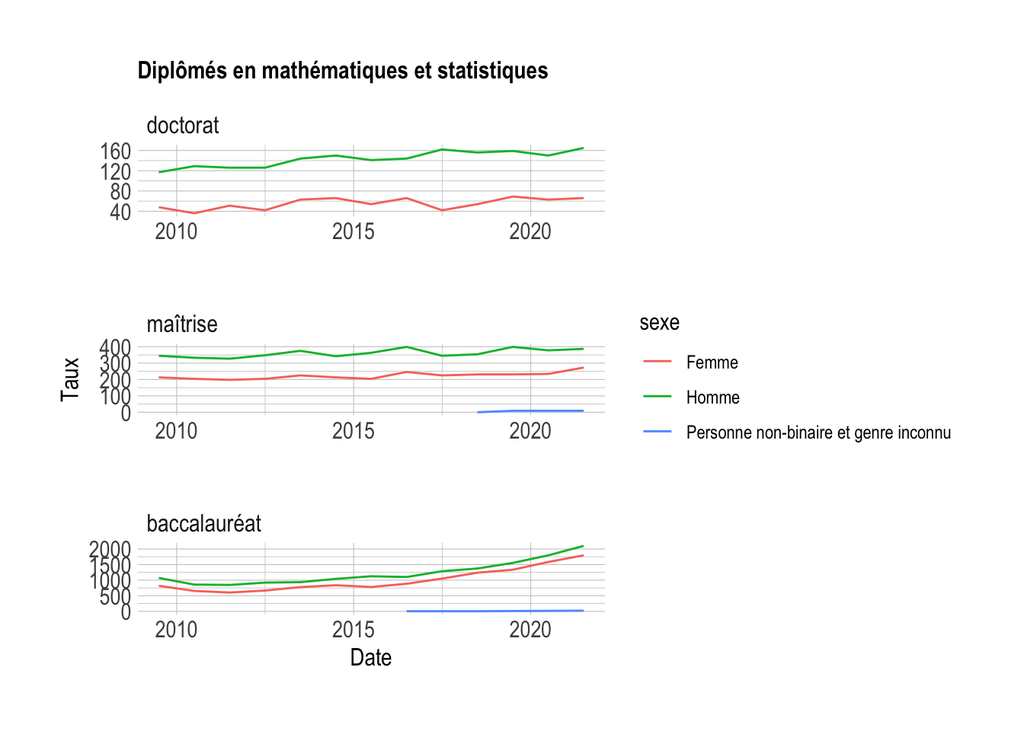

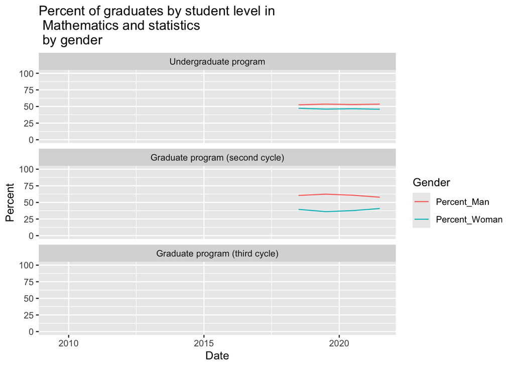

```r
row_2_use = 15
```

## Make some plots of 37-10-0011-01 describing Postsecondary enrolments, by field of study, registration status, program type, credential type and gender

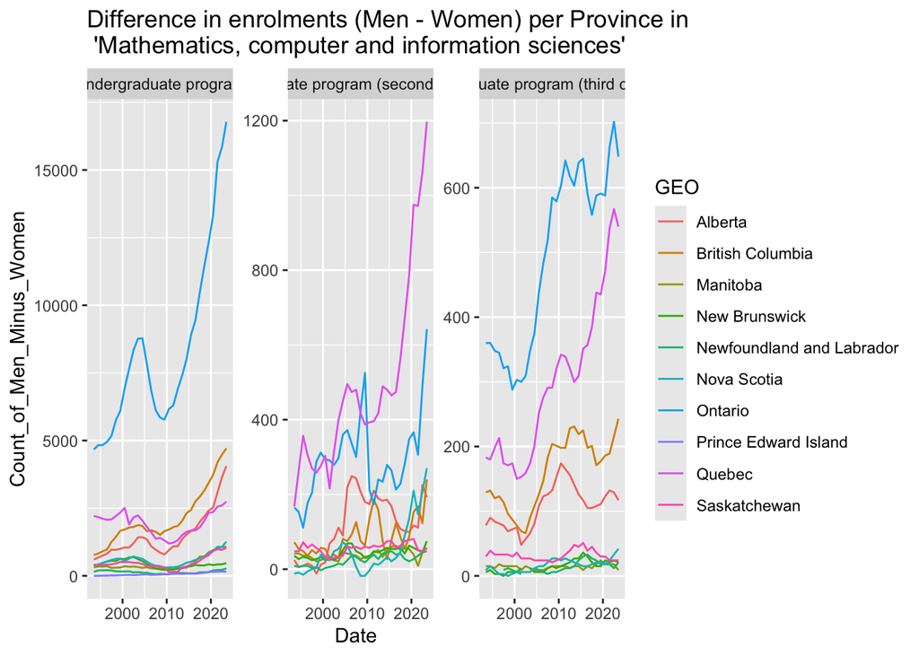

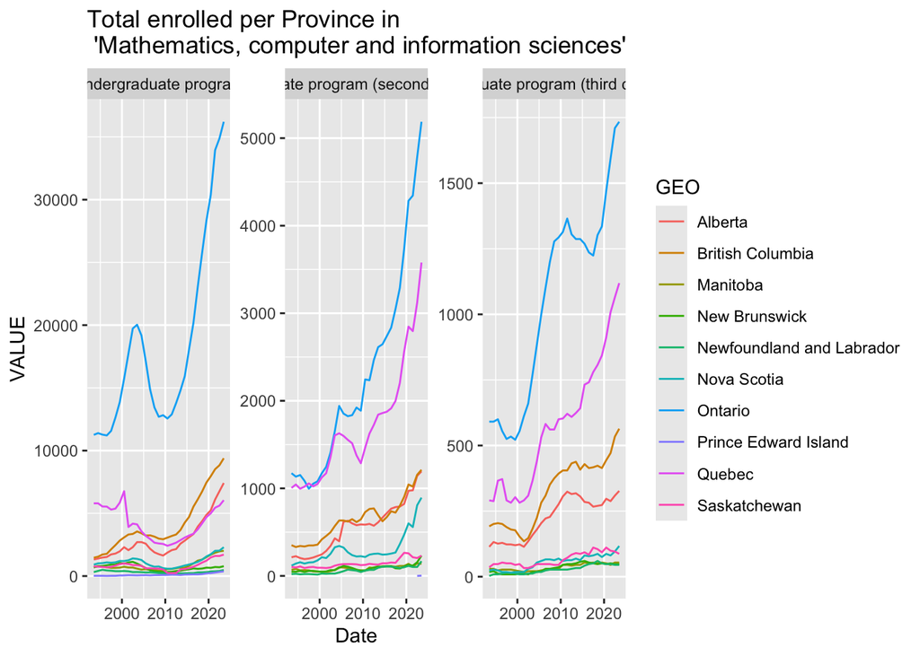

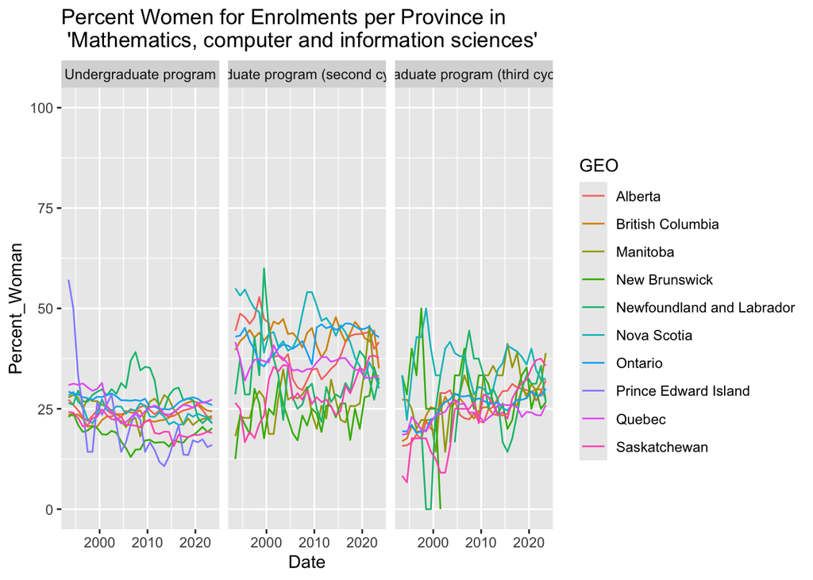